# AI Analytics 3 - Risk Prediction

Alex

2018-02-26

### Read in data and functions

```r
source("2018-02-21-ai-analytics/BDVis.R")
source("2018-02-21-ai-analytics/UniVarAnal.R")
source("2018-02-21-ai-analytics/RiskPrediction.R")
mdl.data<-readRDS("2018-02-21-ai-analytics/mdl.data.RDS")
mdl.strct<-readRDS("2018-02-21-ai-analytics/mdl.strct.RDS")
#saveRDS(mdl.data,"2018-02-21-ai-analytics/mdl.data.RDS")
#saveRDS(mdl.strct,"2018-02-21-ai-analytics/mdl.strct.RDS")
```

## Regression

```r
mdl.glm<-log.reg(mdl.data)
coef.proc.df<-coef.proc(summary(mdl.glm)$coef)
coef.proc.df<-coef.intpt(coef.proc.df,mdl.data,mdl.strct)
summary(mdl.glm)
```

```
##
## Call:
## glm(formula = fml, family = "binomial", data = mdl.data)
##
## Deviance Residuals:
##     Min       1Q   Median       3Q      Max
## -2.1495  -0.2090  -0.1356  -0.0919   3.8911
##
## Coefficients:
##                            Estimate Std. Error z value Pr(>|z|)
## (Intercept)               -7.499845   0.197961 -37.885  < 2e-16 ***
## Age                        0.060753   0.001912  31.776  < 2e-16 ***
## GenderMale                 0.389397   0.037700  10.329  < 2e-16 ***
## RaceChinese               -0.083090   0.092002  -0.903 0.366453
## RaceMalay                  0.296295   0.101301   2.925 0.003446 **
## RaceIndian                -0.087946   0.105941  -0.830 0.406458
## MaritalSingle             -0.764622   0.108805  -7.027 2.10e-12 ***
## MaritalDivorced/Separated -0.489259   0.288686  -1.695 0.090117 .
## MaritalWidowed            -0.564550   0.235351  -2.399 0.016451 *
## MaritalMarried            -0.656606   0.038800 -16.923  < 2e-16 ***
## MediFund                   0.325559   0.053808   6.050 1.44e-09 ***
## DiabetesYear< 1           -0.331230   0.068232  -4.854 1.21e-06 ***
## DiabetesYear1 to 2        -0.253543   0.088359  -2.869 0.004112 **
## DiabetesYear2 to 5        -0.189539   0.058148  -3.260 0.001116 **
## DiabetesYear5 to 10       -0.068183   0.045753  -1.490 0.136164
## PatTypeTTSH               -0.357246   0.070490  -5.068 4.02e-07 ***
## Dyslipidemia              -0.296954   0.087523  -3.393 0.000692 ***
## Hypertension               0.048220   0.069086   0.698 0.485194
## Asthma                    -0.097114   0.077892  -1.247 0.212480
## COPD                       0.317611   0.079402   4.000 6.33e-05 ***
## CKD                        0.348013   0.043813   7.943 1.97e-15 ***
## CHD                        0.133249   0.042288   3.151 0.001627 **
## Heart_F                    0.604493   0.053578  11.283  < 2e-16 ***
## Stroke                     0.419498   0.042253   9.928  < 2e-16 ***
## Retinopathy                0.185715   0.048645   3.818 0.000135 ***
## SPN                        0.249402   0.040904   6.097 1.08e-09 ***
## MajorAmputation            0.594562   0.132373   4.492 7.07e-06 ***
## MinorAmputation            0.197173   0.133185   1.480 0.138753
## BMIUnderweight             0.018081   0.096636   0.187 0.851579
## BMINormal                 -0.456123   0.068973  -6.613 3.76e-11 ***
```

[output cut: 17 more lines]

```
## LDL>=4.1                  -0.015463   0.107527  -0.144 0.885652
## SOC.score                  1.021130   0.206238   4.951 7.38e-07 ***
## Diag.score                 1.832786   0.114531  16.002  < 2e-16 ***
## Drug.score                 1.834063   0.143322  12.797  < 2e-16 ***
## ---
## Signif. codes:  0 '***' 0.001 '**' 0.01 '*' 0.05 '.' 0.1 ' ' 1
##
## (Dispersion parameter for binomial family taken to be 1)
##
##     Null deviance: 33752  on 143752  degrees of freedom
## Residual deviance: 26948  on 143702  degrees of freedom
##   (33 observations deleted due to missingness)
## AIC: 27050
##
## Number of Fisher Scoring iterations: 7
```

## Coefficient

### R coefficient with knitr

```r
coef.df.to.kable(coef.proc.df)
```

```
## Setting cell_spec format as html
```

Variable

OddsRatio

Low95

Up95

Pvalue

Sig

Age

1.06

1.06

1.07

0.0000

***

**Gender**

Male

1.48

1.37

1.59

0.0000

***

**Race**

Chinese

0.92

0.77

1.10

0.3665

Malay

1.34

1.10

1.64

0.0034

Indian

0.92

0.74

1.13

0.4065

**Marital**

Single

0.47

0.38

0.58

0.0000

***

Divorced/Separated

0.61

0.35

1.08

0.0901

.

Widowed

0.57

0.36

0.90

0.0165

Married

0.52

0.48

0.56

0.0000

***

MediFund

1.38

1.25

1.54

0.0000

***

**DiabetesYear**

< 1

0.72

0.63

0.82

0.0000

***

1 to 2

0.78

0.65

0.92

0.0041

2 to 5

0.83

0.74

0.93

0.0011

5 to 10

0.93

0.85

1.02

0.1362

**PatType**

TTSH

0.70

0.61

0.80

0.0000

***

Dyslipidemia

0.74

0.63

0.88

0.0007

***

Hypertension

1.05

0.92

1.20

0.4852

Asthma

0.91

0.78

1.06

0.2125

COPD

1.37

1.18

1.61

0.0001

***

CKD

1.42

1.30

1.54

0.0000

***

CHD

1.14

1.05

1.24

0.0016

Heart_F

1.83

1.65

2.03

0.0000

***

Stroke

1.52

1.40

1.65

0.0000

***

Retinopathy

1.20

1.09

1.32

0.0001

***

SPN

1.28

1.18

1.39

0.0000

***

MajorAmputation

1.81

1.40

2.35

0.0000

***

MinorAmputation

1.22

0.94

1.58

0.1388

**BMI**

Underweight

1.02

0.84

1.23

0.8516

Normal

0.63

0.55

0.73

0.0000

***

Overweight

0.54

0.47

0.61

0.0000

***

Obese I

0.46

0.40

0.53

0.0000

***

Obese II

0.60

0.50

0.72

0.0000

***

Obese III

0.74

0.57

0.96

0.0233

**HbA1c**

<=5

2.46

1.78

3.40

0.0000

***

5.1-6

1.42

1.20

1.67

0.0000

***

6.1-7

0.95

0.81

1.12

0.5439

7.1-8.5

0.87

0.74

1.02

0.0837

.

>8.6

1.22

1.03

1.45

0.0200

**BP**

<120

0.86

0.74

1.01

0.0616

.

120-139

0.53

0.47

0.61

0.0000

***

140-159

0.52

0.45

0.59

0.0000

***

160-179

0.60

0.52

0.70

0.0000

***

>=180

0.61

0.52

0.73

0.0000

***

**LDL**

<2.6

0.57

0.49

0.67

0.0000

***

2.6-3.3

0.67

0.57

0.79

0.0000

***

3.4-4.0

0.67

0.55

0.82

0.0001

***

>=4.1

0.98

0.80

1.22

0.8857

SOC.score

2.78

1.85

4.16

0.0000

***

Diag.score

6.25

4.99

7.82

0.0000

***

Drug.score

6.26

4.73

8.29

0.0000

***

### Visualizing coefficients

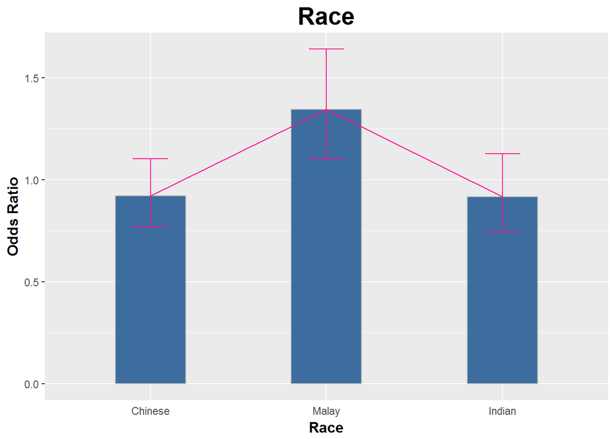

```r
reg.cat.vis("Race",coef.proc.df,trend=F)
```

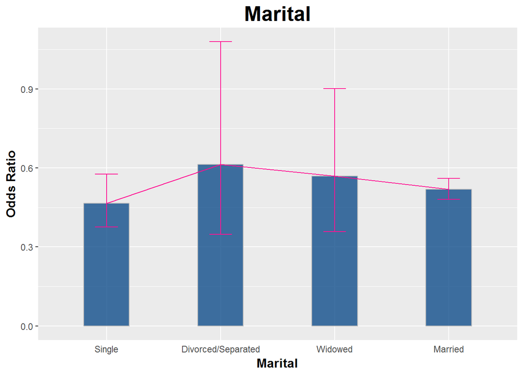

```r
reg.cat.vis("Marital",coef.proc.df,trend=F)
```

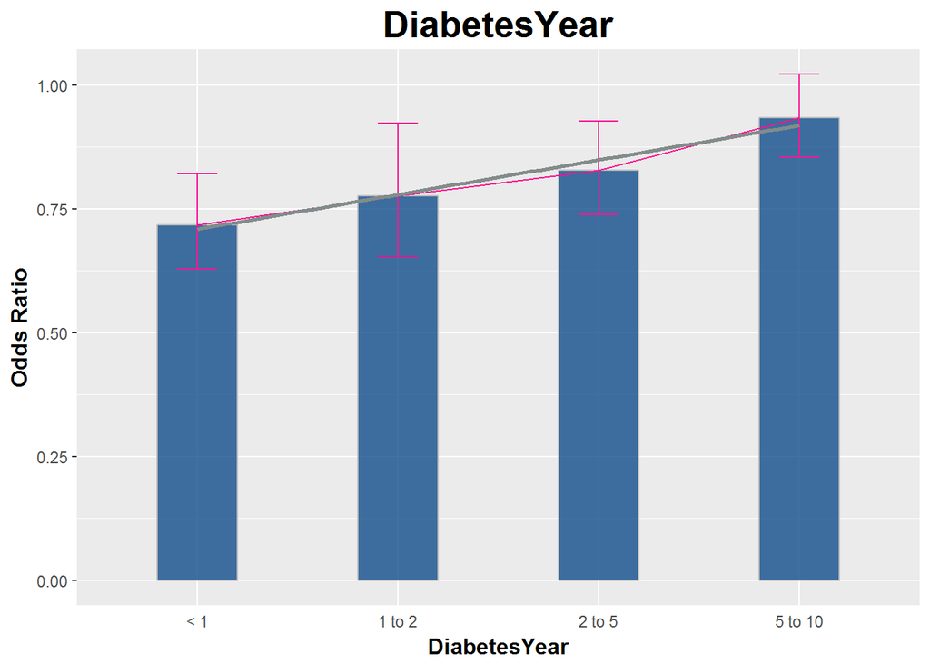

```r
reg.cat.vis("DiabetesYear",coef.proc.df)
```

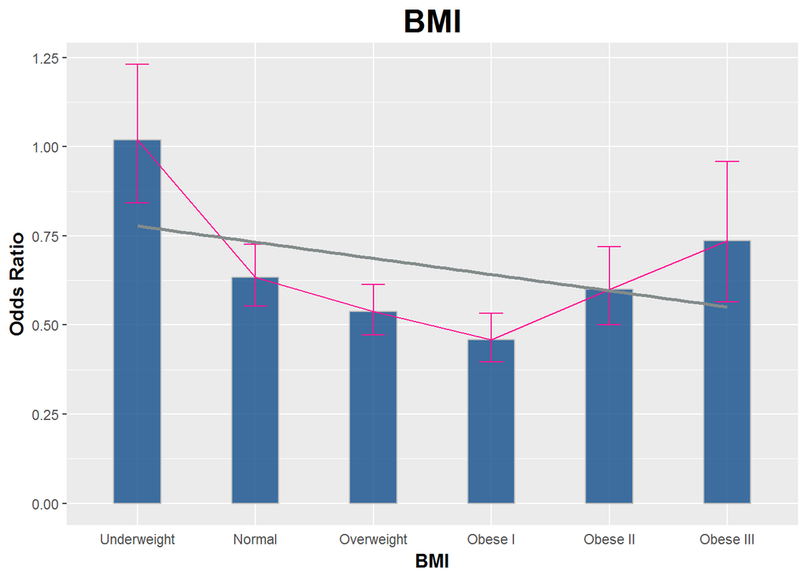

```r
reg.cat.vis("BMI",coef.proc.df)
```

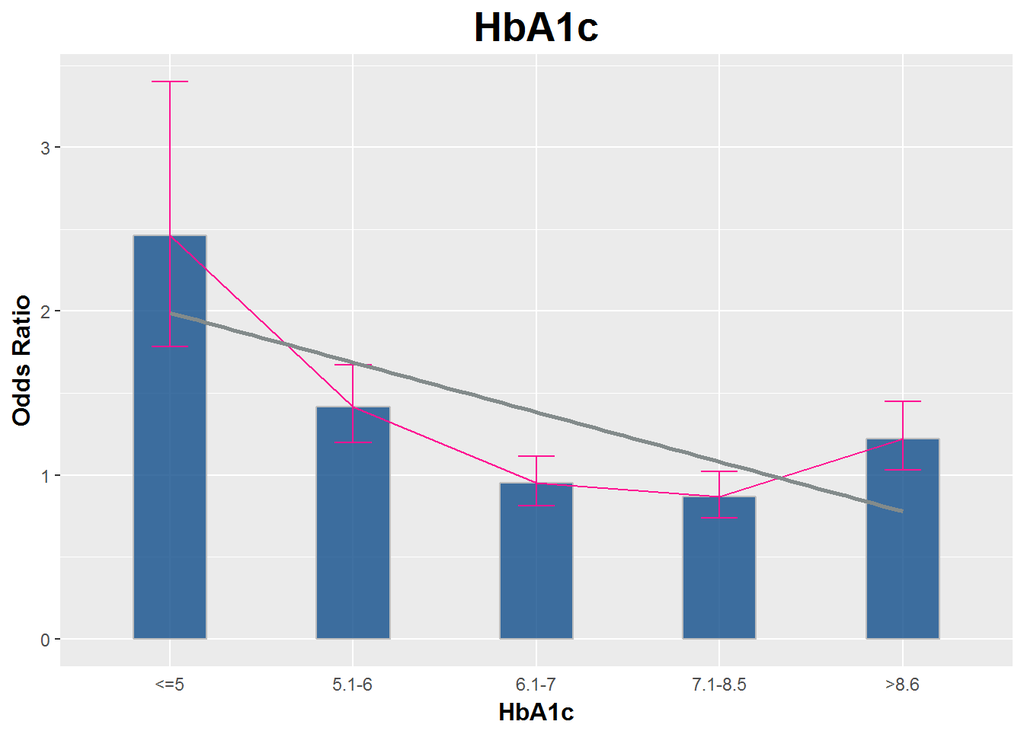

```r
reg.cat.vis("HbA1c",coef.proc.df)
```

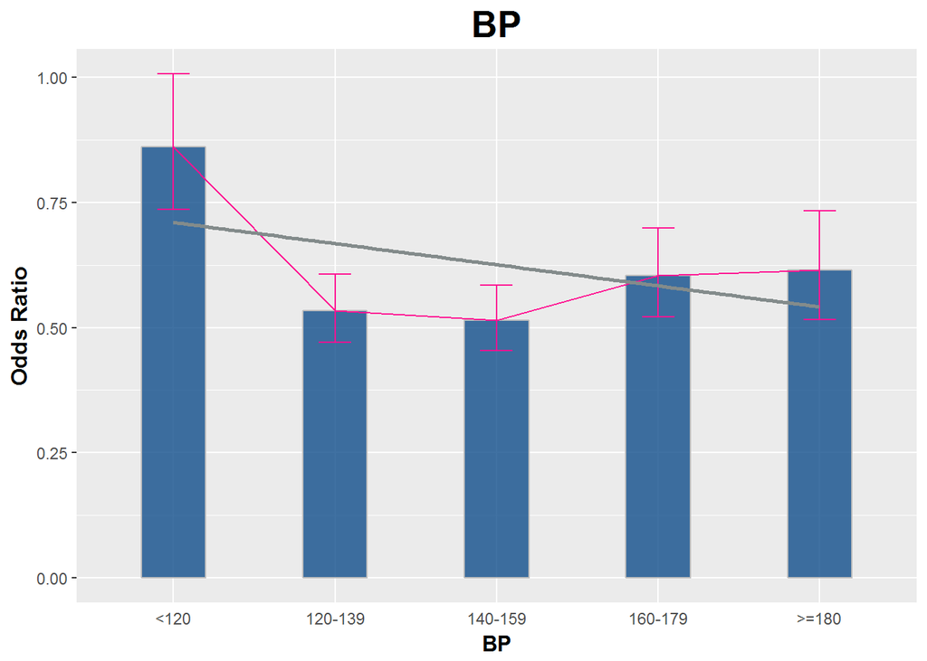

```r
reg.cat.vis("BP",coef.proc.df)
```

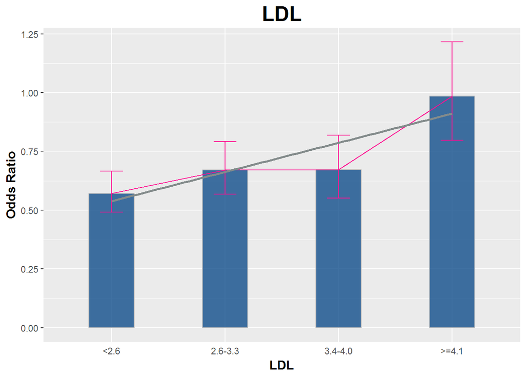

```r
reg.cat.vis("LDL",coef.proc.df)
```

### Parallel variable visualization

This horizontal bar-chart is suitable for presenting the effects of a series of binomial variable

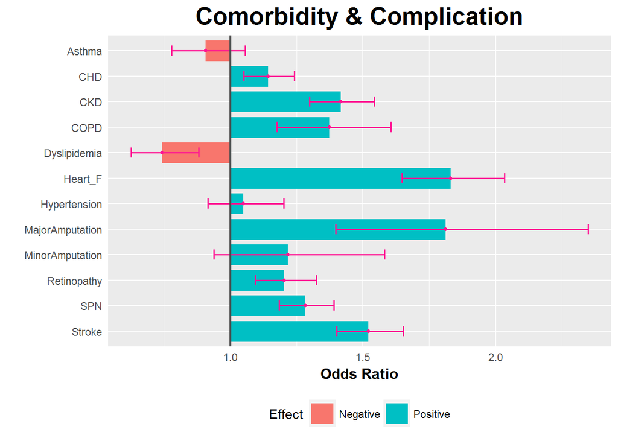

```r
para.coef.df<-coef.proc.df[coef.proc.df$VarGrp=="Comorbidity & Complication",]
para.coef.df<-para.coef.df[rev(order(para.coef.df$Variable)),]
reg.para.var.vis(para.coef.df,"Comorbidity & Complication")
```

## Model validation

### Prediction score

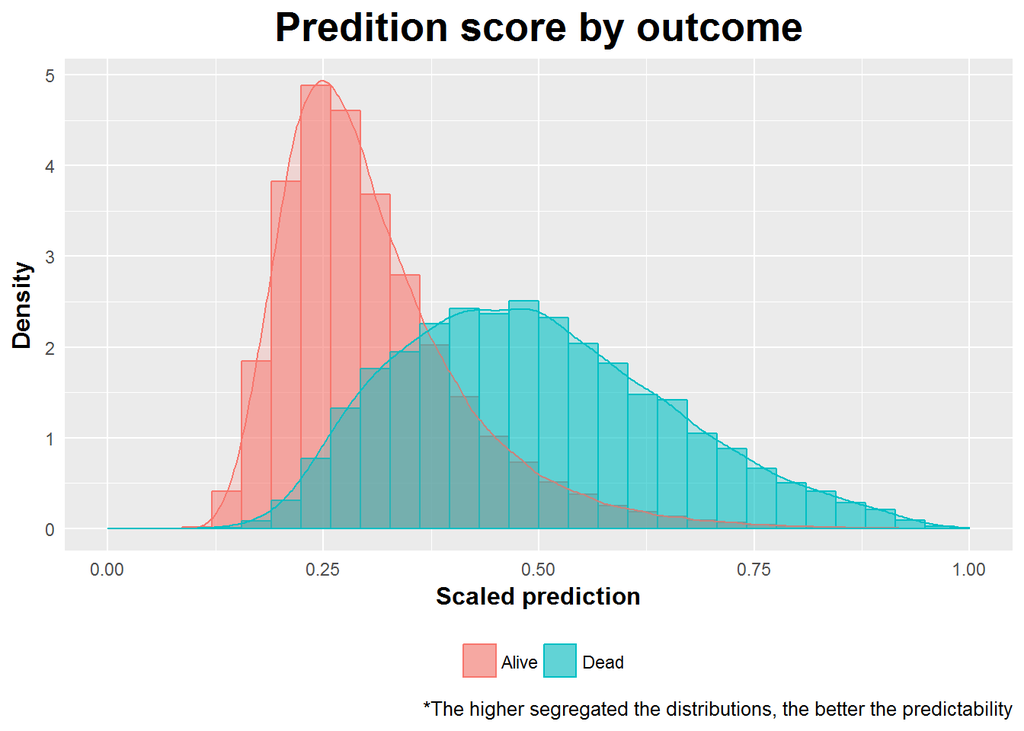

```r
mdl.pred<-pred.score.fun(mdl.glm,mdl.data)
pred.score.dist.vis(mdl.pred)
```

### ROC & AUC

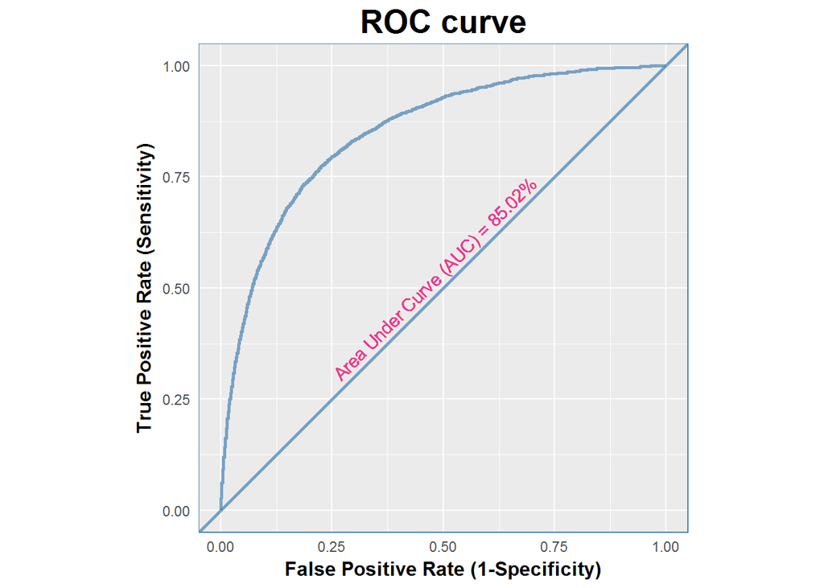

```r
roc.vis(mdl.pred)
```

### Fitting performance

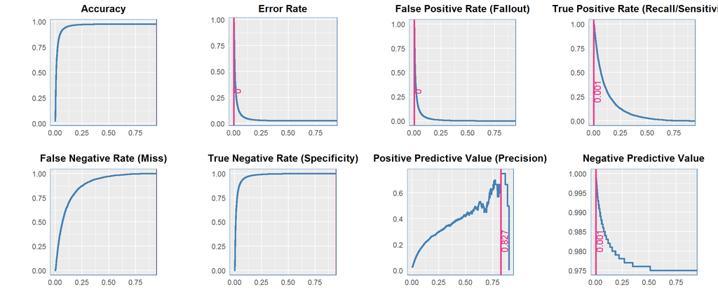

```r
perf.sum.vis(mdl.pred)
```

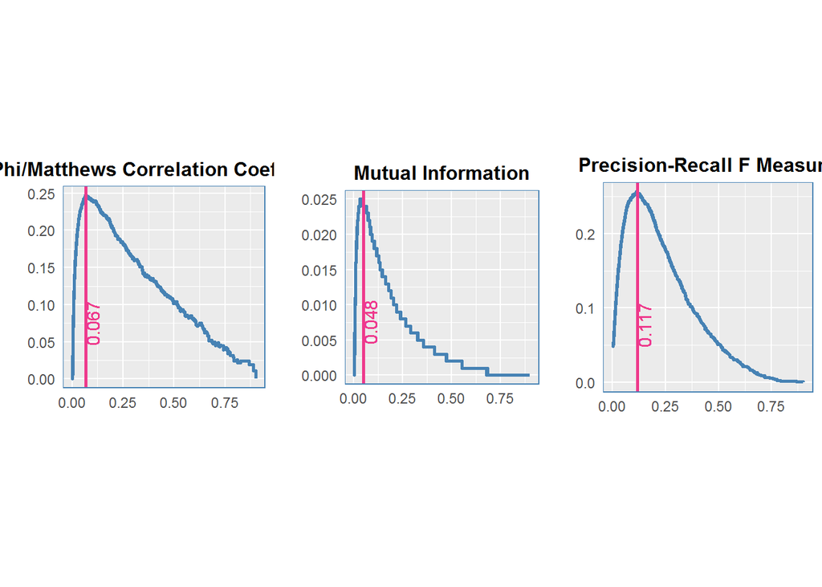

```r
threshold.sel.vis(mdl.pred)
```

### Lift

How much better if using the prediction compare to pure guess

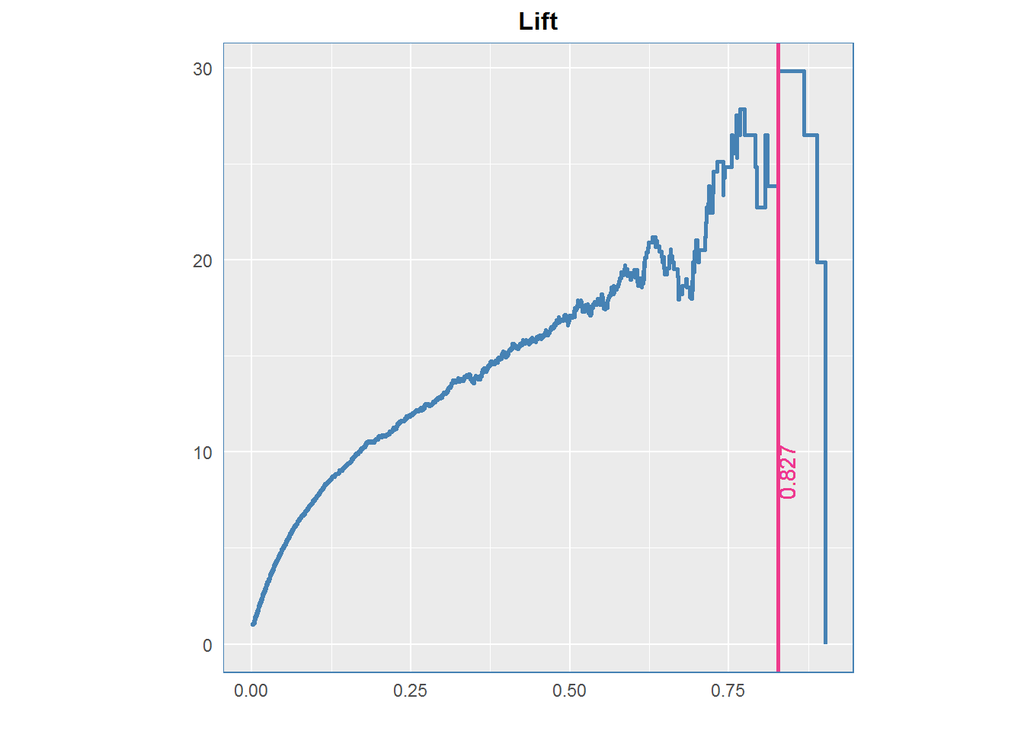

```r
perf.vis(mdl.pred,"lift")
```